# Exploratory Data Analysis of the Red Wine

Ravinder Bahra

April 15th 2018

## Introduction

The following report uses the public red wine dataset collected for the report titled *Modeling wine preferences by data mining from physicochemical properties* by Paulo Cortez.

The dataset consists of 1599 samples, 11 input variables which are based on physiochemical properties of the wine and 1 output variable which is the quality of the wine. The quality of the wine was based on sensory data (taste).

3 wine experts assessed and rated the quality of the wine, a score between 0 to 10 was given where 0 is very bad and 10 is very good.

This report will investigate which of these properties impacts the quality of the wine.

## Univariate Plots and Investigation

### View of the data

```r
head(wine_dataset)
```

| fixed.acidity | volatile.acidity | citric.acid | residual.sugar | chlorides | free.sulfur.dioxide | total.sulfur.dioxide | density | pH | sulphates | alcohol | quality |
| --- | --- | --- | --- | --- | --- | --- | --- | --- | --- | --- | --- |
| 7.4 | 0.70 | 0.00 | 1.9 | 0.076 | 11 | 34 | 0.9978 | 3.51 | 0.56 | 9.4 | 5 |
| 7.8 | 0.88 | 0.00 | 2.6 | 0.098 | 25 | 67 | 0.9968 | 3.20 | 0.68 | 9.8 | 5 |
| 7.8 | 0.76 | 0.04 | 2.3 | 0.092 | 15 | 54 | 0.9970 | 3.26 | 0.65 | 9.8 | 5 |
| 11.2 | 0.28 | 0.56 | 1.9 | 0.075 | 17 | 60 | 0.9980 | 3.16 | 0.58 | 9.8 | 6 |
| 7.4 | 0.70 | 0.00 | 1.9 | 0.076 | 11 | 34 | 0.9978 | 3.51 | 0.56 | 9.4 | 5 |
| 7.4 | 0.66 | 0.00 | 1.8 | 0.075 | 13 | 40 | 0.9978 | 3.51 | 0.56 | 9.4 | 5 |

The table shows that all of the data is numerical, we have the following physicochemical properties we can use to explore the dataset. Some of the explanations for the properites were given as part of the dataset.

- Fixed Acidity - Represents the non volatile acids in the wine
- Volatile Acidity - Too high can results in a vinegar like taste (unpleasant)
- Citric Acid - adds flavour to the wine
- Residual Sugar - The sugar left after the fementation process. Large amounts are found in sweeter wines
- Chlorides - salt content
- Free Sulfur Dioxide - used to prevent microbial growth and prevents the wine from oxidizing
- Density - density of the liquid. Denisity of water is 0.997 g/m<sup>3</sup>
- pH - The acidity of the wine, lower values on the ph scale are more acidic (higher is alkaline). According to the information given with the dataset we’ll find most wines have a ph between 3-4
- Sulphates - added to the wine to increase the sulfur dioxide gas level. Sulfur dioxide gas is an antimicrobial (agent that kills microorganisms )
- Alcohol - The % of alcohol in the wine

#### Statistical summaries of wine properties

```r
summary(wine_dataset)
```

```
##  fixed.acidity   volatile.acidity  citric.acid    residual.sugar
##  Min.   : 4.60   Min.   :0.1200   Min.   :0.000   Min.   : 0.900
##  1st Qu.: 7.10   1st Qu.:0.3900   1st Qu.:0.090   1st Qu.: 1.900
##  Median : 7.90   Median :0.5200   Median :0.260   Median : 2.200
##  Mean   : 8.32   Mean   :0.5278   Mean   :0.271   Mean   : 2.539
##  3rd Qu.: 9.20   3rd Qu.:0.6400   3rd Qu.:0.420   3rd Qu.: 2.600
##  Max.   :15.90   Max.   :1.5800   Max.   :1.000   Max.   :15.500
##    chlorides       free.sulfur.dioxide total.sulfur.dioxide
##  Min.   :0.01200   Min.   : 1.00       Min.   :  6.00
##  1st Qu.:0.07000   1st Qu.: 7.00       1st Qu.: 22.00
##  Median :0.07900   Median :14.00       Median : 38.00
##  Mean   :0.08747   Mean   :15.87       Mean   : 46.47
##  3rd Qu.:0.09000   3rd Qu.:21.00       3rd Qu.: 62.00
##  Max.   :0.61100   Max.   :72.00       Max.   :289.00
##     density             pH          sulphates         alcohol
##  Min.   :0.9901   Min.   :2.740   Min.   :0.3300   Min.   : 8.40
##  1st Qu.:0.9956   1st Qu.:3.210   1st Qu.:0.5500   1st Qu.: 9.50
##  Median :0.9968   Median :3.310   Median :0.6200   Median :10.20
##  Mean   :0.9967   Mean   :3.311   Mean   :0.6581   Mean   :10.42
##  3rd Qu.:0.9978   3rd Qu.:3.400   3rd Qu.:0.7300   3rd Qu.:11.10
##  Max.   :1.0037   Max.   :4.010   Max.   :2.0000   Max.   :14.90
##     quality
##  Min.   :3.000
##  1st Qu.:5.000
##  Median :6.000
##  Mean   :5.636
##  3rd Qu.:6.000
##  Max.   :8.000
```

#### Distributions of wine properties

The following code will loop over the column names and generate histograns of all the wine properties

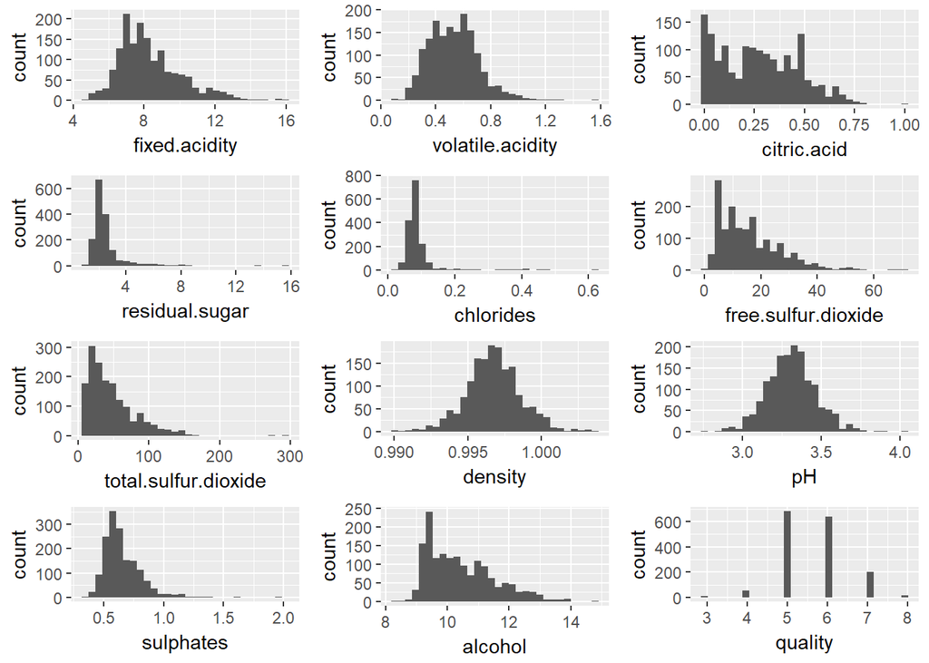

```r
# this code will iterate over all columns/properties in the dataset and create
# a distribution. The distributions wll be added to a list. This list will be
# passed to grid.arrange to arrange a grid view of all the distribution plots

# pull all the names of the columns into a vector variable
column_names <- names(wine_dataset)

# create an empty list to store the plots
plot_list <- list()

# iterate over the column names and create a plot for each property
for (i in 1:length(column_names)){
  # generate a histogram and add to the list
  plot_list[[i]] <- ggplot(aes_string(x=column_names[i]), data=wine_dataset) +
    geom_histogram(bins=30)
}
# pass the list to grid.arrange to display all pl
grid.arrange(grobs = plot_list, ncol = floor(sqrt(length(column_names))))
```

#### Counts for the variable Quality of the wines

```
##
##   3   4   5   6   7   8
##  10  53 681 638 199  18
```

#### Spread of the distributions

```r
# this code section will apply the standard deviation function over

# MARGIN=2 works over columns (1 is rows), apply the standard deviation
# function over all columns
sd_data <- apply(wine_dataset, MARGIN = 2, sd)

# convert to data frame for better viewing
sd_data_df <- data.frame(sd_data)

sd_data_df
```

|  | sd_data |
| --- | --- |
| fixed.acidity | 1.7410963 |
| volatile.acidity | 0.1790597 |
| citric.acid | 0.1948011 |
| residual.sugar | 1.4099281 |
| chlorides | 0.0470653 |
| free.sulfur.dioxide | 10.4601570 |
| total.sulfur.dioxide | 32.8953245 |
| density | 0.0018873 |
| pH | 0.1543865 |
| sulphates | 0.1695070 |
| alcohol | 1.0656676 |
| quality | 0.8075694 |

## Univariate Analysis

Looking at the distribution of the wine quality, most of the wines were rated 5/10 - 6/10.

Most of the distributions are positively skewed, density, ph and quality appear normally distributed.

Citric acid shows a bimodal distribution.

Looking at the summary statistics for each physicochemical property, some of the propeties have a lot of outliers. The most notiable from the distributions and the summary statistics are

- residual sugar
- chlorides
- total sulfur dioxide
- sulphates

In the bivariate section we can begin to look at how these variables effect each other to determine what properties effect the quality.

# Bivariate Analysis

Now we will look at multiple variables together. Pairwuise plots are a good way to see what variables correlate together

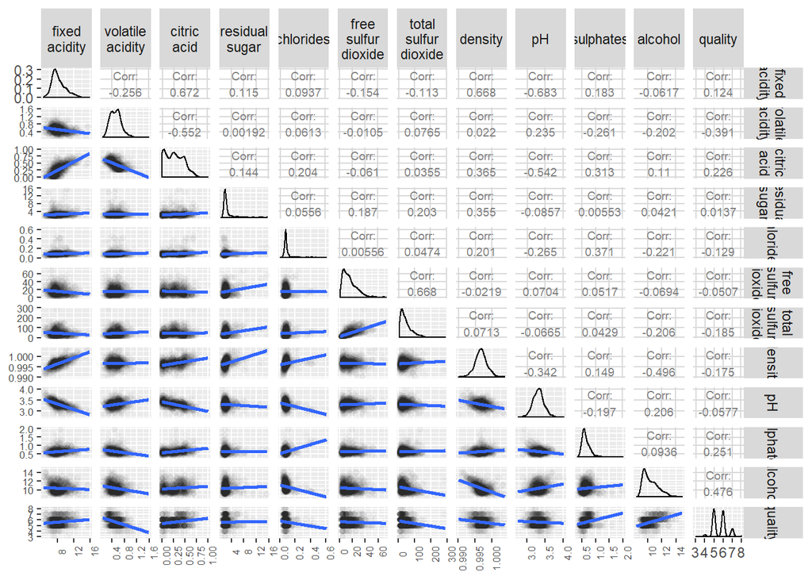

```r
# The function scatter_func returns a scatter plot with the addition of a
# regression line. The default behavior is over ridden by passing a function
# as a parameter in ggpairs

scatter_func <- function(data, mapping,...){
  p <- ggplot(data=data, mapping = mapping) +
    # add alpha level to the plot
    geom_point(alpha=0.01) +
    # add a regression line
    geom_smooth(method = "lm", se = FALSE) +
    #reduce the size of the text so it doesn't overlap
    theme(text = element_text(size=8),
        axis.text.x = element_text(angle=90))
}

colnames <- names(wine_dataset)[1:length(names(wine_dataset))]

ggpairs(wine_dataset,
        columns = 1:ncol(wine_dataset),
        upper = list(continuous = wrap("cor", size = 2.5)),
        lower = list(continuous = scatter_func),
        columnLabels = gsub('.', ' ', colnames, fixed = T),
        labeller = label_wrap_gen(10)
        #diag = list(continuous = diag_func)
        )
```

#### Which variables impact quality

The output variable (quality) is of most interest to us, we’d like to determine which properties of the wine contribute to a greater quality

There are some properties that do correlate with quality. The correlations are not strong but do stand out and are worth looking into for further analysis.

Other correlations not against quality are as follows

- *Total Sulfur Dioxide* and *Free Sulphur Dioxide* corrlate, which isn’t unexpected as total sulfur dioxide contains free sulfur dioxide
- *Citric Acid* and *Fixed Acidity* (0.672) - again this is expected with larger volumes of acid
- *pH* with *Citric Acid* (-0.542) and *pH* with *Fixed Acidity* (-0.683) - again will correlate, higher acidity has a lower PH (higher Ph is more alkaline)
- *Citric Acid* and *Volatile Acidity* (-0.552)
- *Alcohol Content* and *Density* (-0.496)
- *Density* and *Residual Sugar* (0.355)
- *Density* and *pH* (-0.342)

An easier view of the correlations

```r
cor(x=wine_dataset[,2:12], y=wine_dataset$quality)
```

```
##                             [,1]
## volatile.acidity     -0.39055778
## citric.acid           0.22637251
## residual.sugar        0.01373164
## chlorides            -0.12890656
## free.sulfur.dioxide  -0.05065606
## total.sulfur.dioxide -0.18510029
## density              -0.17491923
## pH                   -0.05773139
## sulphates             0.25139708
## alcohol               0.47616632
## quality               1.00000000
```

#### Box plots of quality

Now we can take a look at quality against some of the variables of interest

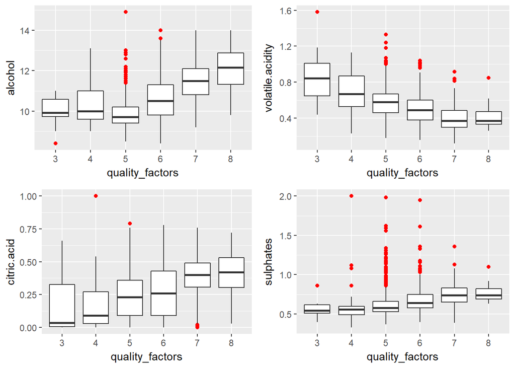

```r
# create a new variable to hold factor version of quality
wine_dataset$quality_factors <- as.factor(wine_dataset$quality)

# create box plots for each property

# alcohol
b_plot_alcohol <- ggplot(aes(x=quality_factors,y=alcohol),
      data=wine_dataset) +
  geom_boxplot(outlier.colour="red")

# volatile acidity
b_plot_acidity <- ggplot(aes(x=quality_factors,y=volatile.acidity),
      data=wine_dataset) +
  geom_boxplot(outlier.colour="red")

# citric acid
b_plot_citric_acid <- ggplot(aes(x=quality_factors,y=citric.acid),
      data=wine_dataset) +
  geom_boxplot(outlier.colour="red")

# sulphates
b_plot_sulphate<- ggplot(aes(x=quality_factors,y=sulphates),
      data=wine_dataset) +
  geom_boxplot(outlier.colour="red")

# arrange plots in a grid
grid.arrange(b_plot_alcohol,b_plot_acidity,b_plot_citric_acid, b_plot_sulphate)
```

### scatter plots

#### code for plotting scatter plots and histograms

```r
# the following code allows us to pass in a property and it will create a
# scatter plot
quality_scatter <- function(wine_property){
  plt <- ggplot(aes_string(x='quality',y=wine_property),data=wine_dataset) +
  geom_point(position='jitter', aes(color=quality), alpha=0.3) +
  geom_smooth(method = 'lm')
  return(plt)
}

# the function creates faceted historgrams which are split by the quality of the
# wine
wine_property_hist <- function(wine_property){
  plt <- ggplot(aes_string(x=wine_property), data=wine_dataset) +
  geom_histogram() +
  #geom_histogram(aes(fill=quality_factors)) +
  facet_wrap(~quality_factors)
  return(plt)
}
```

#### scatter plot of Alcohol vs quality

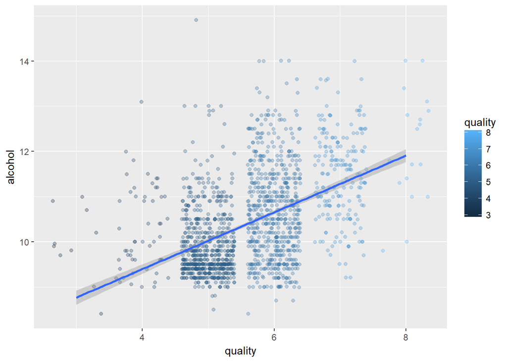

#### histogram of alcohol faceted by quality

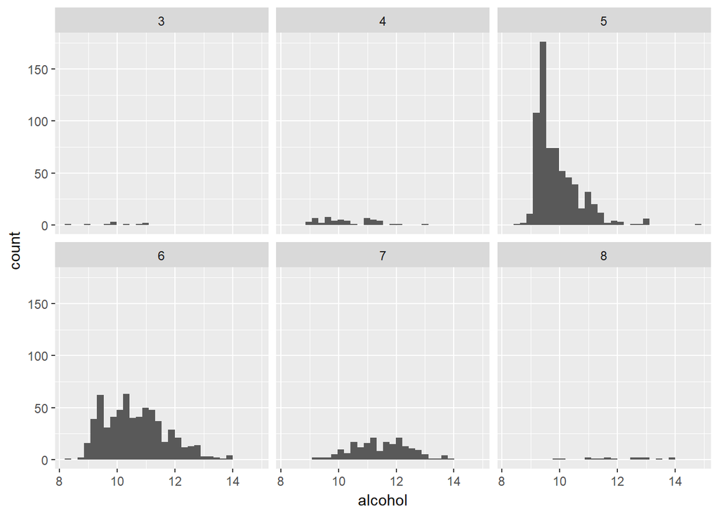

#### scatter plot of Volatile acidity vs quality

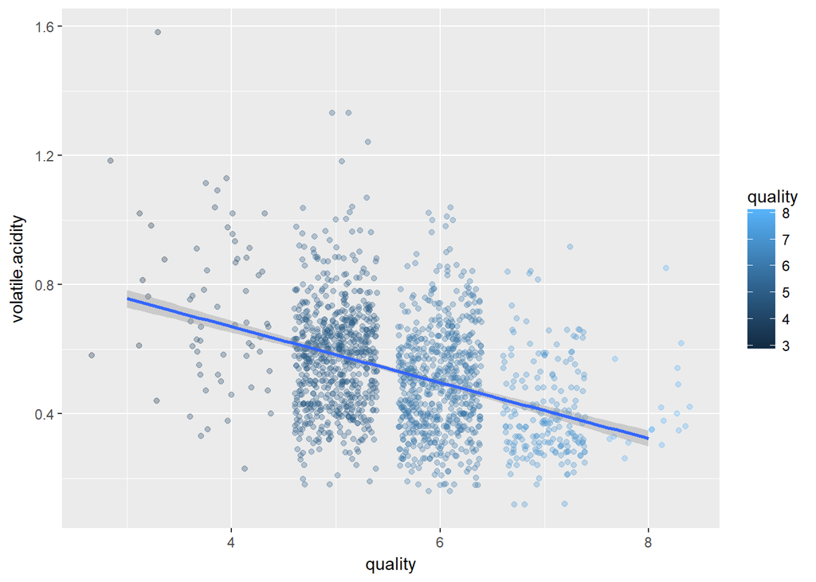

#### histogram of volatile acidity faceted by quality

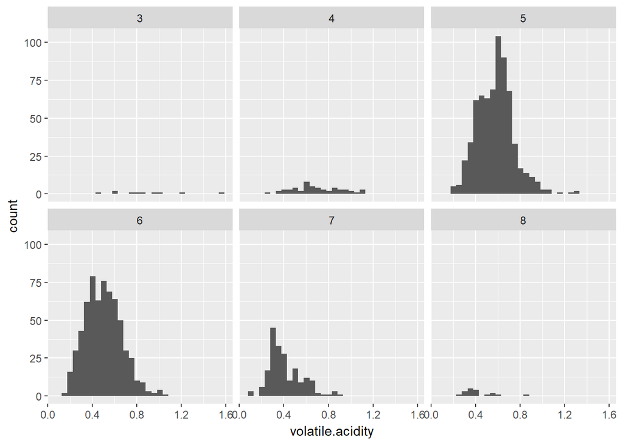

#### scatter plot of citric acid vs quality

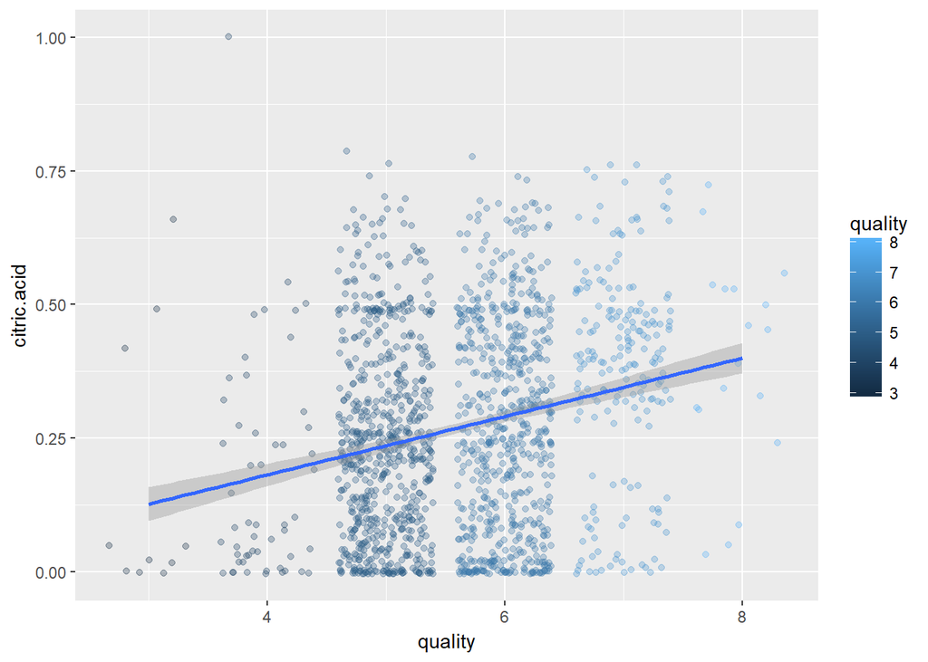

#### histogram of citric acid faceted by quality

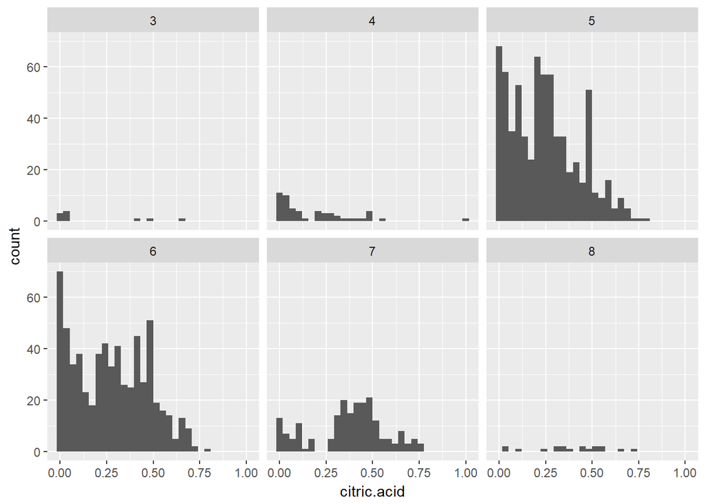

#### scatter plot of sulphates vs quality

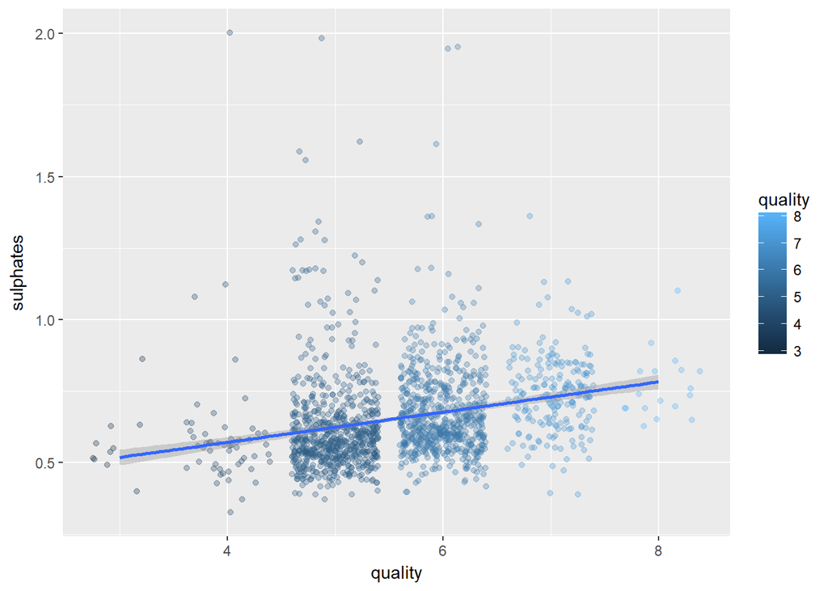

#### histogram of sulphates faceted by quality

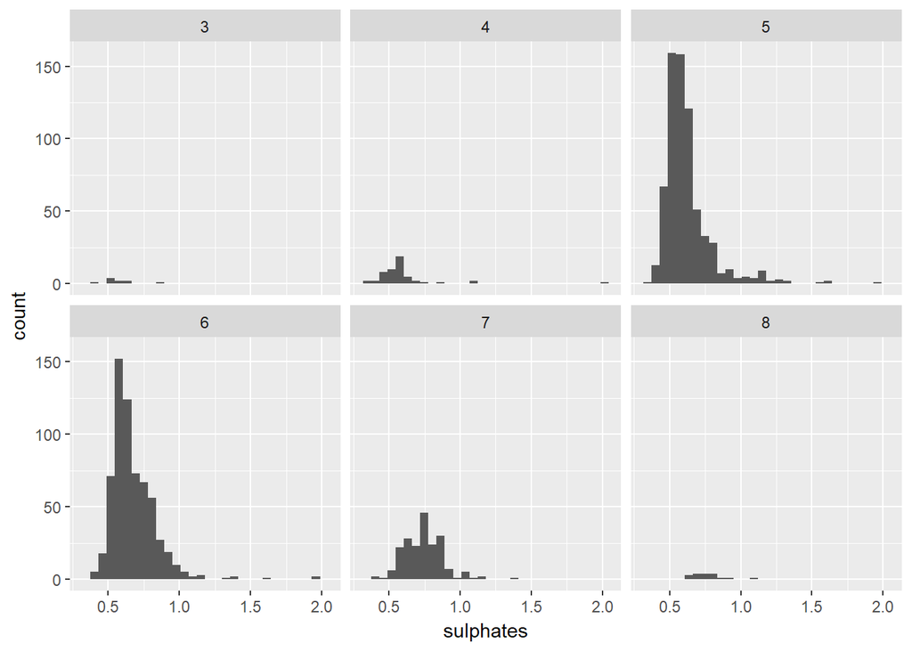

#### Density

The density plot below shows the distribution of density with a line showing where the density of water is.

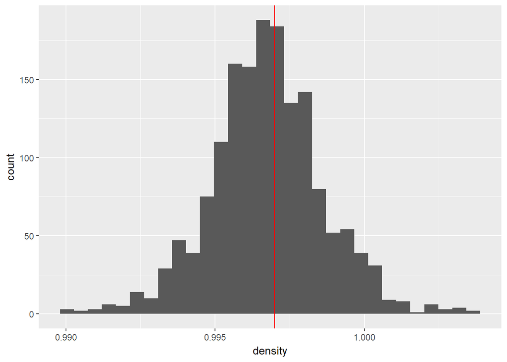

```r
ggplot(aes(x=density), data=wine_dataset) +
  geom_histogram() +
  geom_vline(xintercept=0.997, colour="red")
```

Let’s take a look where the position of the distributions are when using face wrap with alcohol factors.

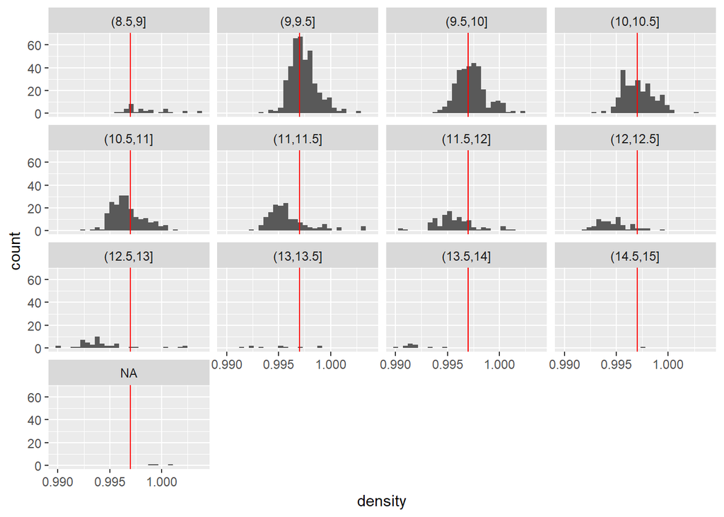

```r
wine_dataset$alcohol_factors <- cut(wine_dataset$alcohol, breaks = seq(8.5,15,0.5))

ggplot(aes(x=density), data=wine_dataset) +
  geom_histogram() +
  geom_vline(xintercept=0.997, colour="red") +
  facet_wrap(~alcohol_factors)
```

#### sugar vs quality, outliers removed

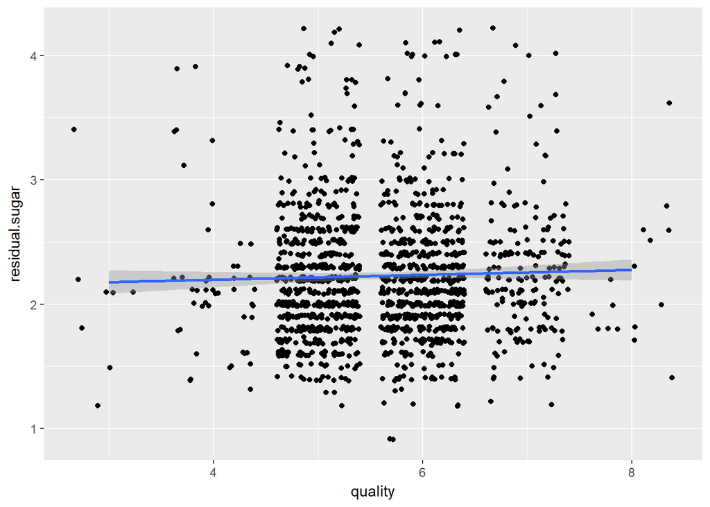

```r
# standard deviation of the residual sugar
sd_rs <- sd(wine_dataset$residual.sugar)

no_outliers <- subset(wine_dataset, residual.sugar < 3*sd_rs)

ggplot(aes(x=quality, y=residual.sugar), data=no_outliers) +
  geom_point(position='jitter') +
  geom_smooth(method = 'lm')
```

```r
cor(x=no_outliers$residual.sugar, y = no_outliers$quality)
```

```
## [1] 0.029257
```

##### acidity and residual sugar

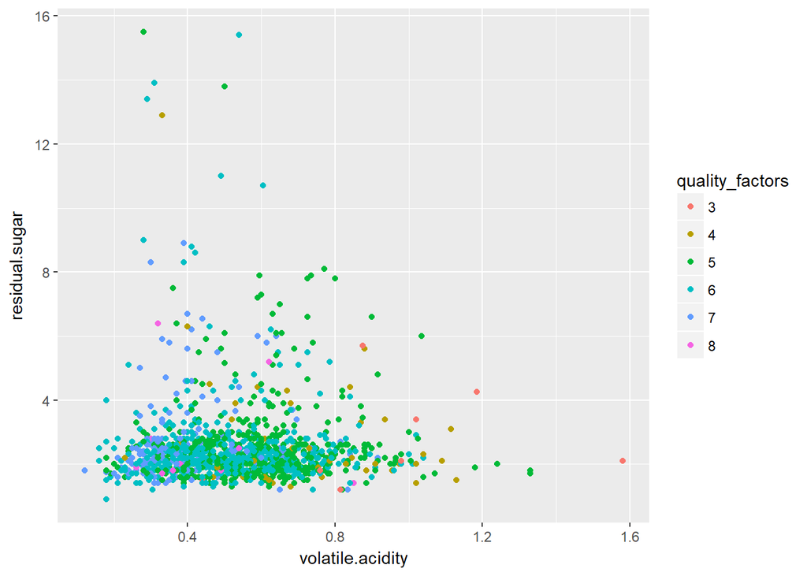

```r
ggplot(aes(x=volatile.acidity, y=residual.sugar), data=wine_dataset) +
  geom_point(aes(color=quality_factors))
```

## Bivariate Plots Analysis

I was surprised to see that residual sugar didn’t correlate with quality. I initially had presumptions that sweeter wines would score higher on quality.

Even removing the outliers did not improve the correlation.

It was noticed that increased alcohol decreases the density of the wine. This is due to the fact that alcohol is less dense than water. This could indicate that less dense wines are seen as better quality

The intial box plots shows the distributions for different quality ratings. An increase in alcohol did show an increase in quality. Is this because of the alcohol content or is the fact the increase in alcohol reduces the density of the liquid.

An increase in citric acid also showed an increase in quality

# Multivariate plots

#### does the total acidity in red wine impact quality?

we can add up the 3 acidic properties and look at acid in general and the effect on the quality of wine

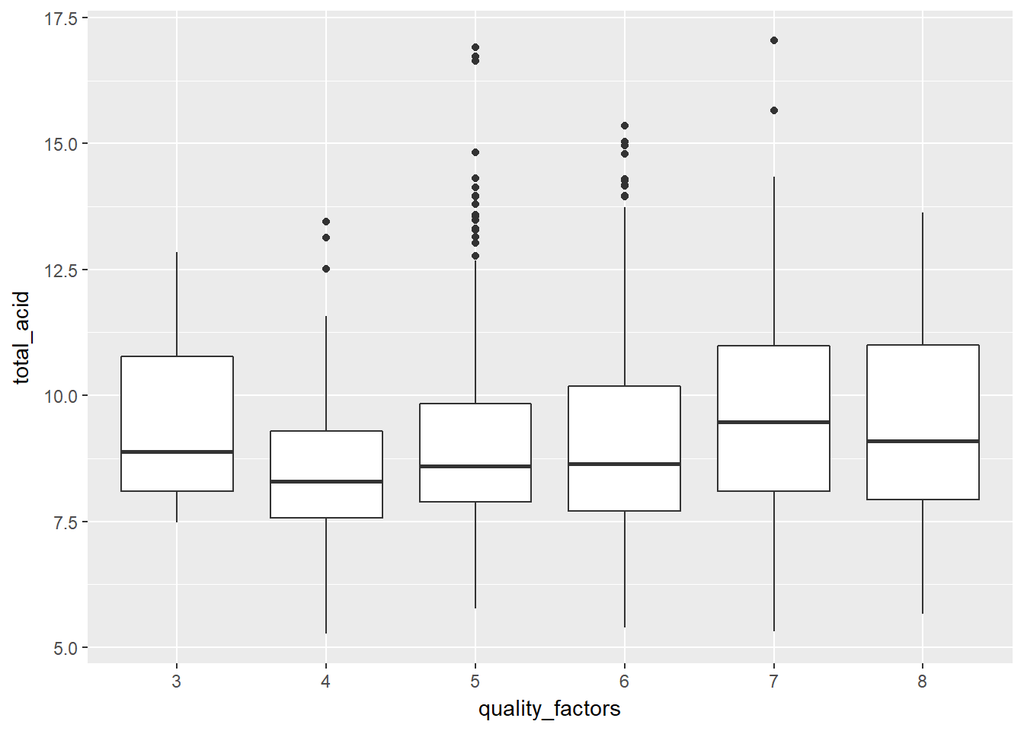

```r
wine_dataset$total_acid = wine_dataset$fixed.acidity +
  wine_dataset$volatile.acidity +
  wine_dataset$citric.acid

ggplot(aes(x=quality_factors,total_acid), data = wine_dataset) +
  geom_boxplot()
```

```r
#ggplot(aes)
```

```r
library(dplyr)
library(reshape2)


mean_acids <- wine_dataset %>%
  group_by(quality) %>%
   summarise(mean_citric = mean(citric.acid),
             mean_fixed_acidity = mean(fixed.acidity),
             mean_volatile_acidity = mean(volatile.acidity))
mean_acids
```

| quality | mean_citric | mean_fixed_acidity | mean_volatile_acidity |
| --- | --- | --- | --- |
| 3 | 0.1710000 | 8.360000 | 0.8845000 |
| 4 | 0.1741509 | 7.779245 | 0.6939623 |
| 5 | 0.2436858 | 8.167254 | 0.5770411 |
| 6 | 0.2738245 | 8.347179 | 0.4974843 |
| 7 | 0.3751759 | 8.872362 | 0.4039196 |
| 8 | 0.3911111 | 8.566667 | 0.4233333 |

```r
# convert to long format data so we can
mdata <- melt(mean_acids, id.vars = c("quality"))

mdata
```

| quality | variable | value |
| --- | --- | --- |
| 3 | mean_citric | 0.1710000 |
| 4 | mean_citric | 0.1741509 |
| 5 | mean_citric | 0.2436858 |
| 6 | mean_citric | 0.2738245 |
| 7 | mean_citric | 0.3751759 |
| 8 | mean_citric | 0.3911111 |
| 3 | mean_fixed_acidity | 8.3600000 |
| 4 | mean_fixed_acidity | 7.7792453 |
| 5 | mean_fixed_acidity | 8.1672540 |
| 6 | mean_fixed_acidity | 8.3471787 |
| 7 | mean_fixed_acidity | 8.8723618 |
| 8 | mean_fixed_acidity | 8.5666667 |
| 3 | mean_volatile_acidity | 0.8845000 |
| 4 | mean_volatile_acidity | 0.6939623 |
| 5 | mean_volatile_acidity | 0.5770411 |
| 6 | mean_volatile_acidity | 0.4974843 |
| 7 | mean_volatile_acidity | 0.4039196 |
| 8 | mean_volatile_acidity | 0.4233333 |

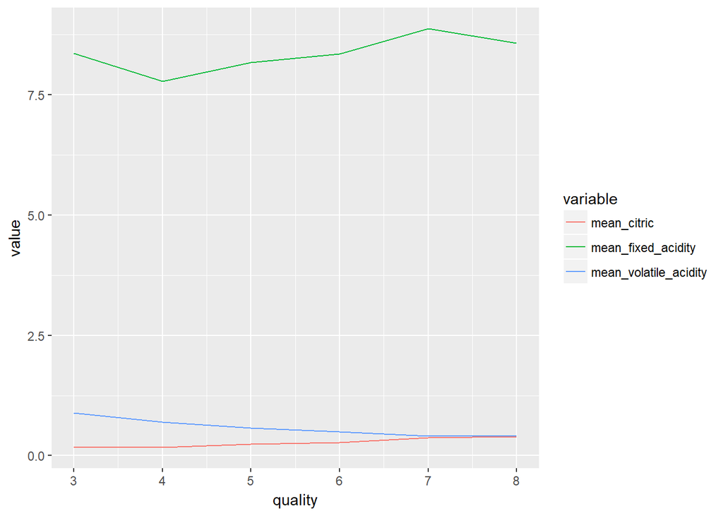

```r
ggplot(aes(x=quality, y=value), data=mdata) +
  geom_line(aes(color = variable))
```

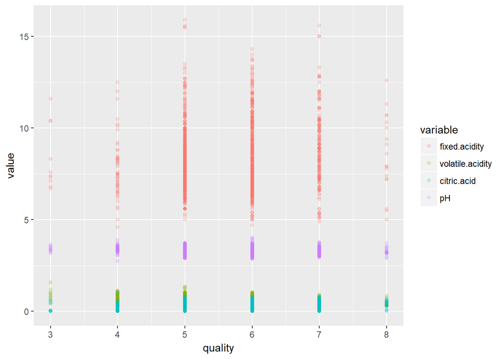

```r
acid_data <- subset(wine_dataset, select = c("fixed.acidity", "volatile.acidity", "citric.acid", "pH", "quality"))


# convert to long format for

acidic_reshape <- melt(acid_data, id.vars = c("quality"))

ggplot(aes(x=quality, y=value), data=acidic_reshape) +
  geom_point(aes(color = variable), alpha=0.2)
```

```r
names(wine_dataset)
```

```
##  [1] "fixed.acidity"        "volatile.acidity"     "citric.acid"
##  [4] "residual.sugar"       "chlorides"            "free.sulfur.dioxide"
##  [7] "total.sulfur.dioxide" "density"              "pH"
## [10] "sulphates"            "alcohol"              "quality"
## [13] "quality_factors"      "alcohol_factors"      "total_acid"
```

the sulfur dioxide againsts total_acid content

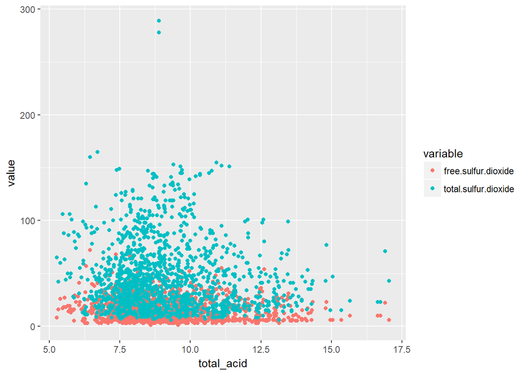

```r
sulfur_data <- subset(wine_dataset, select = c("free.sulfur.dioxide","total.sulfur.dioxide",
                                               "total_acid"))

sulfur_reshape <- melt(sulfur_data, id.vars = c("total_acid"))

ggplot(aes(x=total_acid, y=value), data=sulfur_reshape) +
  geom_point(aes(color=variable))
```

```r
sulfur_grouped <- sulfur_data %>%
  group_by("total_acid") %>%
   summarise(mean_fsd = mean(free.sulfur.dioxide), mean_tsd = mean(total.sulfur.dioxide))
```

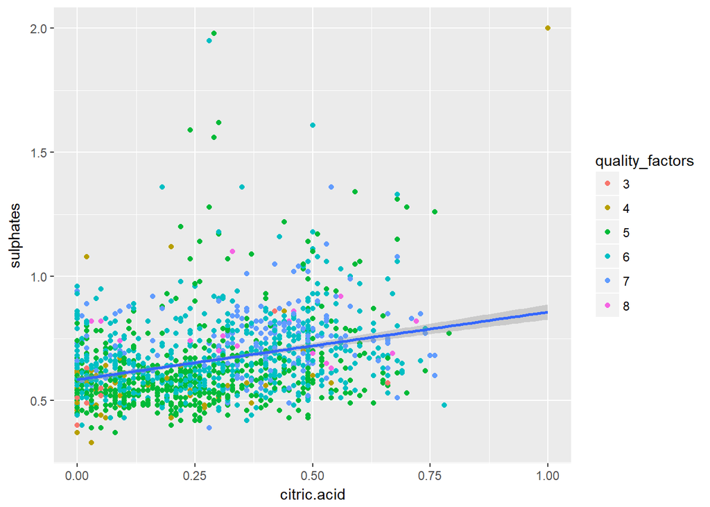

```r
ggplot(aes(x=citric.acid, y=sulphates), data=wine_dataset) +
  geom_point(aes(color=quality_factors)) +
  geom_smooth(method = 'lm')
```